# XGBoost for Image Recognition

# Code Implementation - Train the model

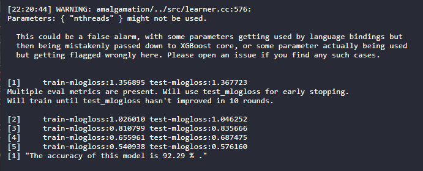

# Code Implementation - Fine-tune the model

- To fine-tune the training model, we changed the “eta” (learning rate) from the default 0.3 to 0.1 and increase “nrounds” (number of iterations) to 300 so that we can maximize the model in terms of accuracy. At the same time, we set L1 regularizer (alpha) and L2 regularizer (lambda) to prevent overfitting of the trees.
- Also, we increase the “max_depth” from the default 6 to 10 to build deeper trees.

```r
set.seed(123)
num_class = length(levels(label))
params = list(
  booster="gbtree",
  eta=0.1,
  max_depth=10,
  lambda=0.1,
  alpha=0.1,
  subsample=0.75,
  colsample_bytree=0.5,
  objective="multi:softprob",
  eval_metric="mlogloss",
  num_class=num_class
)
set.seed(123)
xgb.fit=xgb.train(
  params=params,
  data=xgb.train,
  nrounds=300,
  nthreads=2,
  early_stopping_rounds=10,
  watchlist=list(train=xgb.train,test=xgb.test),
  verbose=1
)
```

# Code Implementation - Predict the model

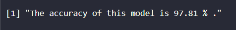

[figure not shown]

```r
xgb.pred = predict(xgb.fit,test.data,reshape=T)
xgb.pred = as.data.frame(xgb.pred)
colnames(xgb.pred) = levels(label)
xgb.pred$prediction = apply(xgb.pred,1,function(x) colnames(xgb.pred)[which.max(x)])
xgb.pred$label = test.label
result = (sum(xgb.pred$prediction==xgb.pred$label)/nrow(xgb.pred))*100
print(paste("The accuracy of this model is", result, "%","."))

data <- as.data.frame(xgb.fit$evaluation_log)
ggplot(data = data ) + geom_line(aes(x = iter, y = test_mlogloss))
```

# Resources

https://en.wikipedia.org/wiki/MNIST_database

https://www.youtube.com/watch?v=jxuNLH5dXCs

https://towardsdatascience.com/a-visual-guide-to-gradient-boosted-trees-8d9ed578b33

https://towardsdatascience.com/a-visual-guide-to-gradient-boosted-trees-8d9ed578b33

https://www.analyticsvidhya.com/blog/2018/06/comprehensive-guide-for-ensemble-models/

https://analyticsindiamag.com/primer-ensemble-learning-bagging-boosting/#:~:text=Bagging%20is%20a%20way%20to,based%20on%20the%20last%20classification

https://towardsdatascience.com/ensemble-methods-bagging-boosting-and-stacking-c9214a10a205

https://www.analyticsvidhya.com/blog/2021/09/gradient-boosting-algorithm-a-complete-guide-for-beginners/

https://www.ritchievink.com/blog/2018/11/19/algorithm-breakdown-why-do-we-call-it-gradient-boosting/

https://datascience.stackexchange.com/questions/61501/what-is-the-difference-between-gradient-descent-and-gradient-boosting-are-they#:~:text=So%20the%20connection%20is%20this,gradient%20by%20introducing%20new%20models.

https://machinelearningmastery.com/gentle-introduction-gradient-boosting-algorithm-machine-learning/

# Annex

- For simplicity, we will derive the output value $\gamma_{j,m}$

$${\gamma_{2,1}=\ argmin_{\gamma} \sum_{x_i\in R_{ij}} L(y_i,F_{m-1}(x_i)+\gamma)}\\ = L(y_2,F_{m-1}(x_2)+\gamma) +L(y_3,F_{m-2}(x_3)+\gamma)\\ We\ can\ approximate\ the\ loss\ function\ with\ second\ order\ Taylor\ Polynomials\ and\ we\ get:\\L(y_2,F_{m-1}(x_2)+\gamma) +L(y_3,F_{m-2}(x_3)+\gamma)\\\approx L(y_2,F_{m-1}(x_2)) +L(y_3,F_{m-1}(x_3))\\+[\frac{d(y_2,F_{m-1}(x_2))}{dF()} +\frac{d(y_3,F_{m-1}(x_3))}{dF()}]\gamma\\+\frac{1}{2}[\frac{d^2(y_3,F_{m-1}(x_3))}{dF()^2} +\frac{d^2(y_3,F_{m-1}(x_3))}{dF()^2}]\gamma^2$$

$$\frac{d(L(y_2,F_{m-1}(x_2)+\gamma) +L(y_3,F_{m-2}(x_3)+\gamma))}{d\gamma}\\\approx
[\frac{d(y_2,F_{m-1}(x_2))}{dF()} +\frac{d(y_3,F_{m-1}(x_3))}{dF()}]\gamma\\+[\frac{d^2(y_3,F_{m-1}(x_3))}{dF()^2} +\frac{d^2(y_3,F_{m-1}(x_3))}{dF()^2}]\gamma^2 = 0$$

$$\\solving\ for\ \gamma, we \ get:\\\gamma=\frac{-[\frac{d(y_2,F_{m-1}(x_2))}{dF()} +\frac{d(y_3,F_{m-1}(x_3))}{dF()}]}{[\frac{d^2(y_3,F_{m-1}(x_3))}{dF()^2} +\frac{d^2(y_3,F_{m-1}(x_3))}{dF()^2}]} \\=\frac{y_2 - \frac{e^{log(odds)}}{1+e^{log(odds)}}+y_3 - \frac{e^{log(odds)}}{1+e^{log(odds)}}}{p_2*(1-p_2)+p_3*(1-p_3)}\\=\frac{(y_2-p_2)+(y_3-p_3)}{p_2*(1-p_2)+p_3*(1-p_3)}\\=\frac{Residual_2+Residual_3}{p_2*(1-p_2)+p_3*(1-p_3)}$$